# Analysis Findings Report

My analyis focused on key areas such as date, to get insight on the periodic traffic of the account, like how often tweets are generated. secondly i analysed the numerator ratings as it's best indicator of the what the account user thought of the dog. To find out the most likely channel or device from which tweets originated from, i had to analyze the tweet source. I considered the highest indicator for the best dog to be the amount of retweets and likes each of the pictures got. Below are recorded observation from my analysis.

### Observations

**2016 recorded the highest tweet volume**, While its monthly tweet activities appeared to be less than the only two monthly activities present in 2015. **With respect to monthly tweets, 2015 recorded the 2 highest tweets in November and December** which surpasses every other month across the three year period presented in the data. November with 300 tweets, while **December boasts of 388 tweets being the highest monthly tweet activity.**

*Note that there are only 8 months of data in 2017 and the records could increase by the end of its cycle.*

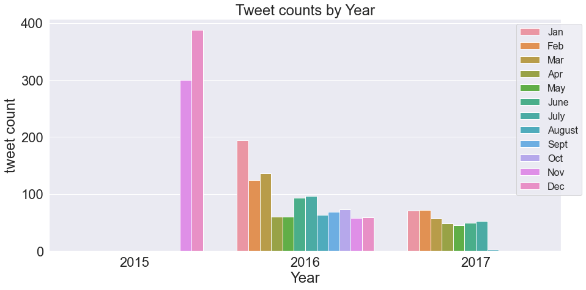

The three year interval as obtained from analysis has an approximate **average dog rating of 13** and **contains 307 dogs** of **214 predicted breeds**. The top five breeds are;

1. golden retriever : 28
2. Pembroke : 17
3. Labrador retriever : 15
4. Samoyed : 13
5. Chihuahua : 11

**Atticus** received the highest dog rating at 1776, after it was posted on the 4th of july (*a true '**American dog**' dog indeed as captioned in the tweet*). The name was obtained from the *text* column.

*I would add that the rating does not bestow on him the best dog considering it did not receive the highest number of likes or retweets. This is just my opinion.*

**Tweets from the handle at different times, were generated from four different channels**:

- Twitter for iPhone - 2042,
- Vine - Make a Scene - 91,
- Twitter Web Client - 31,
- TweetDeck - 11

The user's primary means of tweet is an iPhone and an occasional use of other channels.  
**NB:** Vine app shutdown as a consequence of revenue issues.

**The Most posted Dog breeds are**;

- golden retriever - 139
- Labrador retriever - 95
- Pembroke - 88
- Chihuahua - 79
- pug - 54

There are four unique dog stages **(pupper, puppo, doggo and floofer)** observed in my analysis. however there are dogs that can have more than one dog stage. **344** of the dogs post had dog stage(s) assigned to them, while the rest were not associated with any dog stage.

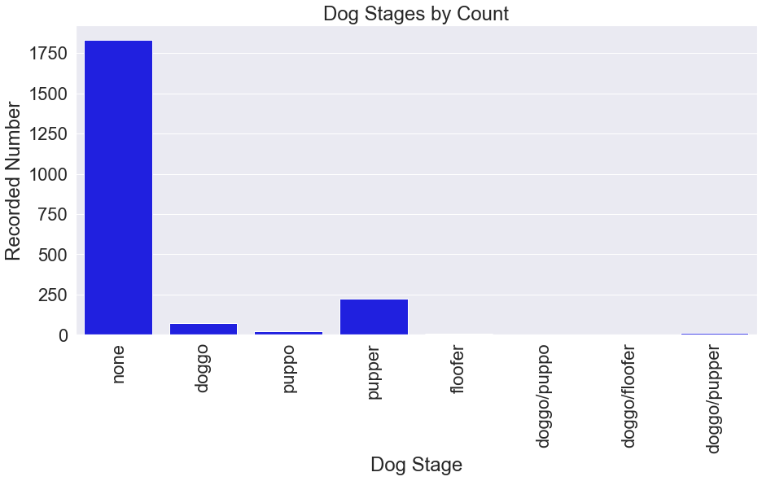

On the average, WeRateDogs twitter handle writes approximately one hundred and eleven (111) characters per tweet.

The average *retweet_counts* and *favorite_counts* are approximately 2225 and 7544 respectively. *Atticus*, the dog with the highest rating of 1776/10 appear to have an above average retweets, but well below average likes. It also falls significatly below the winning dog on likes and retweets which ironically has a 13/10 numerator rating compared to Atticus'. The dog with the highest likes and retweets is a Labrador retriever belonging to the **doggo** dog_stage and famously known for having their lives in order. It's also rumoured that they understed their taxes🤣🤣🤣.

Finally it is important to note that our image prediction model has an average accuracy rate of 61% which is fairly okay.

## The Winner based on likes and retweets

### A Labrador retriever

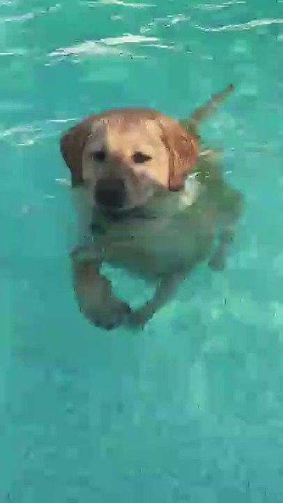

> Most Liked and retweeted dog